# Bilirubin concentrations and Ascities levels in Primary Biliary Cirrhosis.

## 10.4 Validation

```r
model_fw2ols <- ols(Bili~ sgot + copper + protime + triglyc + alb + hepatem + plat, data = pbc4, x = TRUE, y = TRUE)

validate(model_fw2ols)
```

```
          index.orig training   test optimism index.corrected  n
R-square      0.5634   0.5691 0.5498   0.0193          0.5441 40
MSE           0.4648   0.4562 0.4792  -0.0229          0.4877 40
g             0.8312   0.8333 0.8241   0.0092          0.8220 40
Intercept     0.0000   0.0000 0.0074  -0.0074          0.0074 40
Slope         1.0000   1.0000 0.9981   0.0019          0.9981 40
```

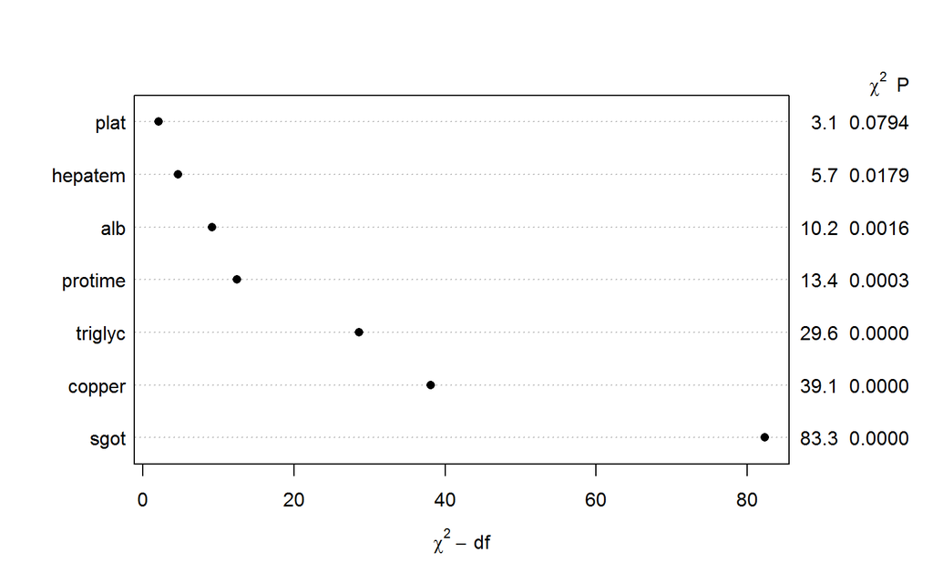

```r
plot(anova(model_fw2ols))
```

According to the anova here, sgot has the highest predictive power amongst all variables, followed by copper and triglyc.

## 10.5 Improving the model

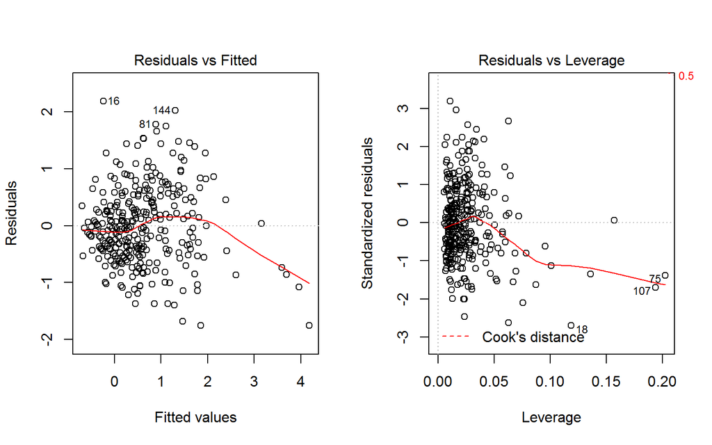

```r
par(mfrow = c(1,2)); plot(model_fw2, which = c(1, 5))
```

There were some issues with the outlier values, with some observations going above 2 Residuals, and thus, I decided to remove them in order to see whether there was any increase in the R square value or not, though all of them fell within the Cook’s distance. The observations removed were: 144, 67, 18 and 16.

```r
model_fw2del2 <- lm(Bili~ sgot + copper + protime + triglyc + alb + hepatem + plat, data = pbc4[-16,])
summary(model_fw2del2)
```

```
Call:
lm(formula = Bili ~ sgot + copper + protime + triglyc + alb +
    hepatem + plat, data = pbc4[-16, ])

Residuals:
    Min      1Q  Median      3Q     Max
-1.7879 -0.4401 -0.0403  0.4286  2.0185

Coefficients:
              Estimate Std. Error t value Pr(>|t|)
(Intercept) -1.4224959  0.6355715  -2.238  0.02594 *
sgot         0.0067943  0.0007234   9.392  < 2e-16 ***
copper       0.0032617  0.0005085   6.414 5.42e-10 ***
protime      0.1563371  0.0425290   3.676  0.00028 ***
triglyc      0.0036820  0.0006530   5.639 3.93e-08 ***
alb         -0.3262313  0.1002805  -3.253  0.00127 **
hepatem      0.2587039  0.1039357   2.489  0.01334 *
plat        -0.0007075  0.0004267  -1.658  0.09832 .
---
Signif. codes:  0 '***' 0.001 '**' 0.01 '*' 0.05 '.' 0.1 ' ' 1

Residual standard error: 0.6801 on 303 degrees of freedom
Multiple R-squared:  0.5756,    Adjusted R-squared:  0.5658
F-statistic:  58.7 on 7 and 303 DF,  p-value: < 2.2e-16
```

```r
# There was a slight increase in R squared value

model_fw2del3 <- lm(Bili~ sgot + copper + protime + triglyc + alb + hepatem + plat, data = pbc4[-c(144,67,18,16),])
summary(model_fw2del3)
```

```
Call:
lm(formula = Bili ~ sgot + copper + protime + triglyc + alb +
    hepatem + plat, data = pbc4[-c(144, 67, 18, 16), ])

Residuals:
     Min       1Q   Median       3Q      Max
-1.71126 -0.44546 -0.03502  0.41381  1.79616

Coefficients:
              Estimate Std. Error t value Pr(>|t|)
(Intercept) -1.6510779  0.6151885  -2.684  0.00768 **
sgot         0.0072521  0.0007210  10.058  < 2e-16 ***
copper       0.0035702  0.0005117   6.977 1.94e-11 ***
protime      0.1593541  0.0410947   3.878  0.00013 ***
triglyc      0.0036630  0.0006320   5.796 1.72e-08 ***
alb         -0.2942032  0.0971443  -3.029  0.00267 **
hepatem      0.2768070  0.1004704   2.755  0.00623 **
plat        -0.0007010  0.0004129  -1.698  0.09059 .
---
Signif. codes:  0 '***' 0.001 '**' 0.01 '*' 0.05 '.' 0.1 ' ' 1

Residual standard error: 0.6564 on 300 degrees of freedom
Multiple R-squared:  0.5948,    Adjusted R-squared:  0.5853
F-statistic:  62.9 on 7 and 300 DF,  p-value: < 2.2e-16
```

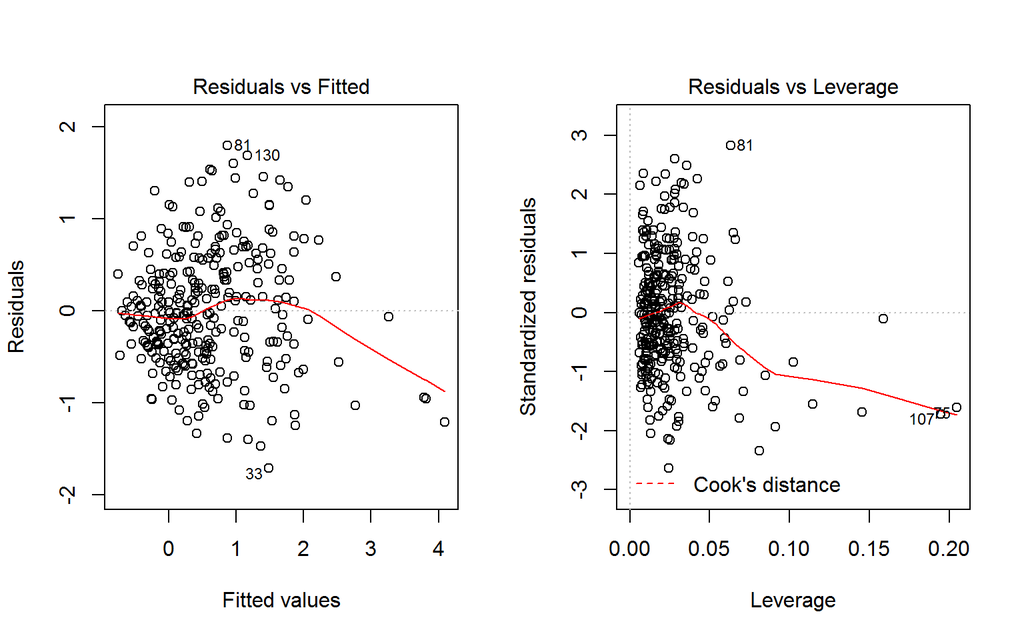

```r
# The R squared value was thus increased by removing the outlier values,

par(mfrow = c(1,2)); plot(model_fw2del3, which = c(1, 5))
```

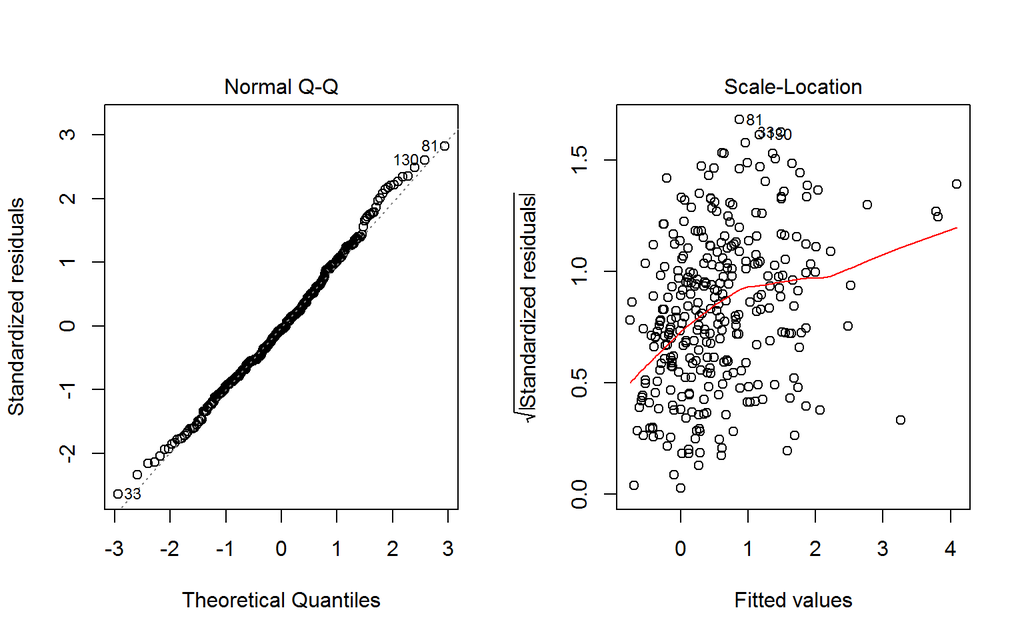

```r
par(mfrow = c(1,2)); plot(model_fw2del3, which = c(2, 3))
```

```r
summary(model_fw2del3)
```

```
Call:
lm(formula = Bili ~ sgot + copper + protime + triglyc + alb +
    hepatem + plat, data = pbc4[-c(144, 67, 18, 16), ])

Residuals:
     Min       1Q   Median       3Q      Max
-1.71126 -0.44546 -0.03502  0.41381  1.79616

Coefficients:
              Estimate Std. Error t value Pr(>|t|)
(Intercept) -1.6510779  0.6151885  -2.684  0.00768 **
sgot         0.0072521  0.0007210  10.058  < 2e-16 ***
copper       0.0035702  0.0005117   6.977 1.94e-11 ***
protime      0.1593541  0.0410947   3.878  0.00013 ***
triglyc      0.0036630  0.0006320   5.796 1.72e-08 ***
alb         -0.2942032  0.0971443  -3.029  0.00267 **
hepatem      0.2768070  0.1004704   2.755  0.00623 **
plat        -0.0007010  0.0004129  -1.698  0.09059 .
---
Signif. codes:  0 '***' 0.001 '**' 0.01 '*' 0.05 '.' 0.1 ' ' 1

Residual standard error: 0.6564 on 300 degrees of freedom
Multiple R-squared:  0.5948,    Adjusted R-squared:  0.5853
F-statistic:  62.9 on 7 and 300 DF,  p-value: < 2.2e-16
```

```r
exp(coef(model_fw2del3))
```

```
(Intercept)        sgot      copper     protime     triglyc         alb
  0.1918430   1.0072785   1.0035766   1.1727532   1.0036697   0.7451251
    hepatem        plat
  1.3189118   0.9992993
```

```r
exp(confint(model_fw2del3))
```

```
                 2.5 %    97.5 %
(Intercept) 0.05717096 0.6437489
sgot        1.00585026 1.0087087
copper      1.00256649 1.0045877
protime     1.08164588 1.2715345
triglyc     1.00242220 1.0049188
alb         0.61546709 0.9020976
hepatem     1.08230289 1.6072473
plat        0.99848766 1.0001115
```

## 10.6 Predictions

```r
p <- datadist(pbc4)
options(datadist = "p")
model_fw2del3ols <- ols(Bili~ sgot + copper + protime + triglyc + alb + hepatem + plat, data = pbc4[-c(144,67,18,16),], x = TRUE, y = TRUE)

predictions <- Predict(model_fw2del3ols, hepatem = c(0,1), sgot = seq(25, 100) )
tbl_df(predictions)
```

```
# A tibble: 152 x 10
    sgot copper protime triglyc   alb hepatem  plat   yhat  lower  upper
   <int>  <dbl>   <dbl>   <dbl> <dbl>   <dbl> <dbl>  <dbl>  <dbl>  <dbl>
 1    25   73.0    10.6     108  3.55       0   258 -0.350 -0.506 -0.193
 2    26   73.0    10.6     108  3.55       0   258 -0.342 -0.498 -0.187
 3    27   73.0    10.6     108  3.55       0   258 -0.335 -0.490 -0.181
 4    28   73.0    10.6     108  3.55       0   258 -0.328 -0.481 -0.175
 5    29   73.0    10.6     108  3.55       0   258 -0.321 -0.473 -0.169
 6    30   73.0    10.6     108  3.55       0   258 -0.313 -0.464 -0.163
 7    31   73.0    10.6     108  3.55       0   258 -0.306 -0.456 -0.157
 8    32   73.0    10.6     108  3.55       0   258 -0.299 -0.447 -0.150
 9    33   73.0    10.6     108  3.55       0   258 -0.292 -0.439 -0.144
10    34   73.0    10.6     108  3.55       0   258 -0.284 -0.431 -0.138
# ... with 142 more rows
```

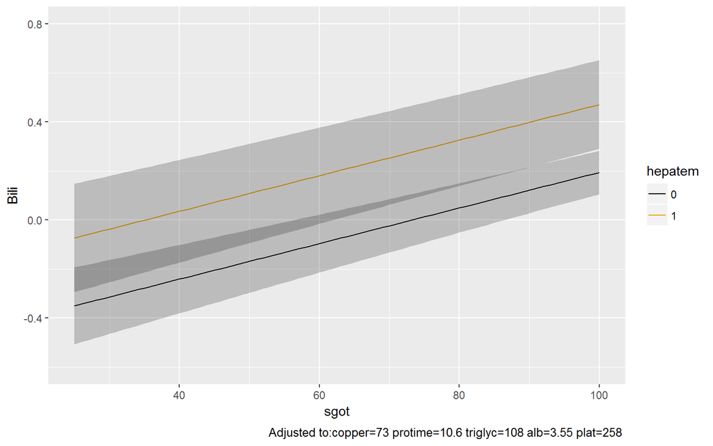

```r
ggplot(Predict(model_fw2del3ols, sgot = 25:100, hepatem = c(0,1)))
```

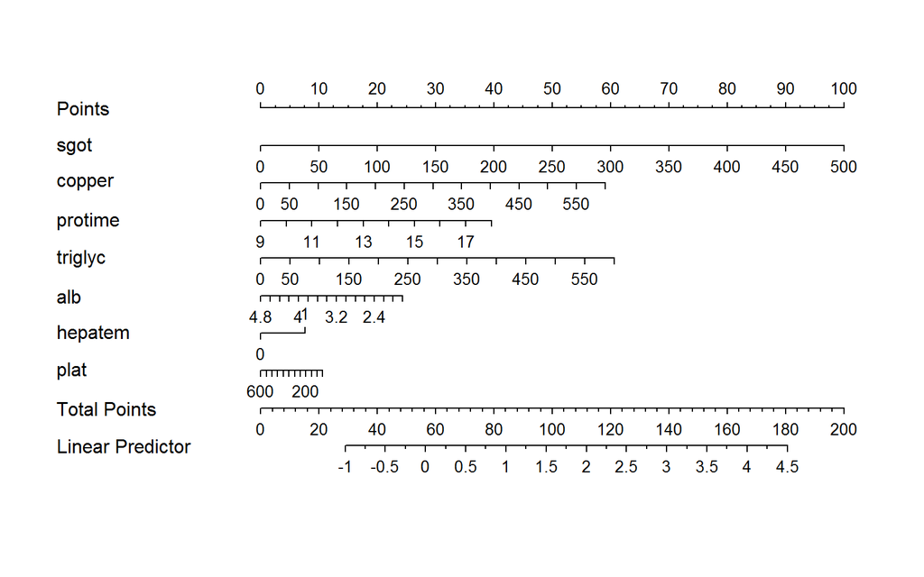

```r
plot(nomogram(model_fw2del3ols))
```

Here, sgot has the highest impact on the prediction of Bilirubin concentrations, followed by triglyc and copper.

## 10.7 Final Model

```r
model_fw2del3ols
```

```
Linear Regression Model

 ols(formula = Bili ~ sgot + copper + protime + triglyc + alb +
     hepatem + plat, data = pbc4[-c(144, 67, 18, 16), ], x = TRUE,
     y = TRUE)

                Model Likelihood     Discrimination
                   Ratio Test           Indexes
 Obs     308    LR chi2    278.20    R2       0.595
 sigma0.6564    d.f.            7    R2 adj   0.585
 d.f.    300    Pr(> chi2) 0.0000    g        0.852

 Residuals

      Min       1Q   Median       3Q      Max
 -1.71126 -0.44546 -0.03502  0.41381  1.79616


           Coef    S.E.   t     Pr(>|t|)
 Intercept -1.6511 0.6152 -2.68 0.0077
 sgot       0.0073 0.0007 10.06 <0.0001
 copper     0.0036 0.0005  6.98 <0.0001
 protime    0.1594 0.0411  3.88 0.0001
 triglyc    0.0037 0.0006  5.80 <0.0001
 alb       -0.2942 0.0971 -3.03 0.0027
 hepatem    0.2768 0.1005  2.76 0.0062
 plat      -0.0007 0.0004 -1.70 0.0906
```

```r
summary(model_fw2del3ols)
```

```
             Effects              Response : Bili

 Factor  Low    High  Diff.  Effect    S.E.     Lower 0.95 Upper 0.95
 sgot     80.60 151.9  71.30  0.517080 0.051409  0.415910   0.618240
 copper   41.75 123.0  81.25  0.290080 0.041578  0.208260   0.371900
 protime  10.00  11.1   1.10  0.175290 0.045204  0.086332   0.264250
 triglyc  84.00 146.0  62.00  0.227110 0.039184  0.149990   0.304220
 alb       3.31   3.8   0.49 -0.144160 0.047601 -0.237830  -0.050486
 hepatem   0.00   1.0   1.00  0.276810 0.100470  0.079091   0.474520
 plat    199.75 322.5 122.75 -0.086044 0.050681 -0.185780   0.013691
```

```r
exp(confint(model_fw2del3ols))
```

```
               2.5 %    97.5 %
Intercept 0.05717096 0.6437489
sgot      1.00585026 1.0087087
copper    1.00256649 1.0045877
protime   1.08164588 1.2715345
triglyc   1.00242220 1.0049188
alb       0.61546709 0.9020976
hepatem   1.08230289 1.6072473
plat      0.99848766 1.0001115
```

```r
exp(coef(model_fw2del3ols))
```

```
Intercept      sgot    copper   protime   triglyc       alb   hepatem
0.1918430 1.0072785 1.0035766 1.1727532 1.0036697 0.7451251 1.3189118
     plat
0.9992993
```

For every 1 increase in the log Bili value, The sgot, copper, protime, triglyc and hepatem values are going to increase, while albumin and plat values are supposed to go down. Those who have had hepatem had a significant increase in the transformed Bili concentrations of about 1.319. The 95% CI was (1.08, 1.60) As the the log Bili concentrations go up by 1mg/dl, the triglyc, plat, sgot and copper values are increased by almost 1 mg/dl, 1 cubic ml/1000, 1 U/ml and 1 ug/day respectively, (The 95% C.I. of (1.002, 1.004), (0.99, 1.00), (1.005, 1.008) and (1.002, 1.004) respectively) For a unit increase in log Bili, the albumin concentrations go down, and there is a slight increase in the protime (by 1.17 seconds). (95% CI of (0.61, 0.9) and (1.08,1.27) respectively).

# 11 Task 11 Logistic Regression

## 11.1 Spearman Rho Squared

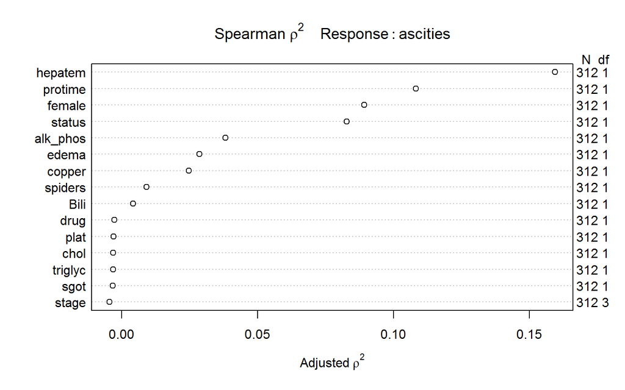

```r
spear.ascities <- spearman2(ascities ~ alk_phos + protime + triglyc + chol + female + copper + sgot + plat + stage + status + Bili + drug + spiders + edema + hepatem, data = pbc2)

plot(spear.ascities)
```

On the basis of the spearman Rho squared plot, I decided to go ahead with the first 5 variables, since I had a small number of observations and limited degrees of freedom to spend. I then made a kitchen sink model using these 5 predictors.

## 11.2 Kitchen Sink Model

```r
logmodel_ks_lrm <- lrm(ascities~ hepatem + protime + female + status + alk_phos, data = pbc2, x = T, y = T)
anova(logmodel_ks_lrm)
```

```
                Wald Statistics          Response: ascities

 Factor     Chi-Square d.f. P
 hepatem    20.37      1    <.0001
 protime     2.10      1    0.1471
 female     25.11      1    <.0001
 status      0.31      1    0.5783
 alk_phos   11.82      1    0.0006
 TOTAL      69.37      5    <.0001
```

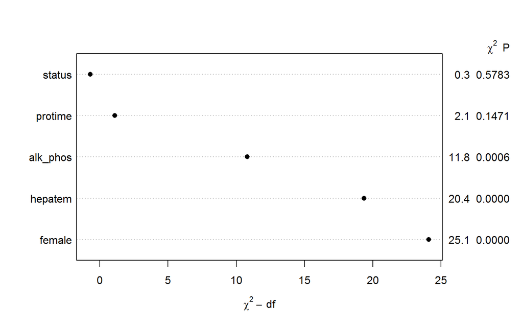

```r
plot(anova(logmodel_ks_lrm))
```

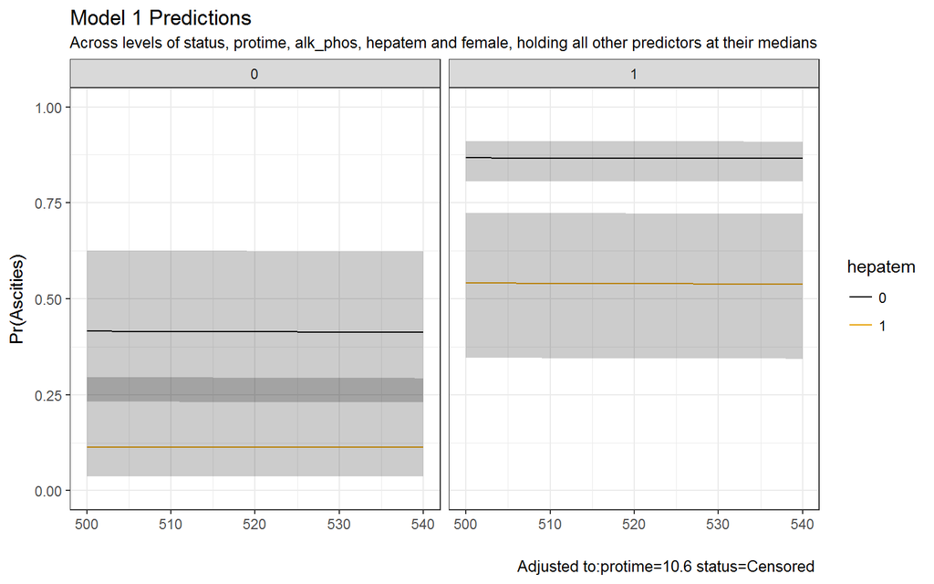

```r
ggplot(Predict(logmodel_ks_lrm, alk_phos = 500:540, hepatem = c(0,1), female =c(0,1), fun=plogis)) +
  theme_bw() +
  labs(x = "",
  y = "Pr(Ascities)", title = "Model 1 Predictions", subtitle = "Across levels of status, protime, alk_phos, hepatem and female, holding all other predictors at their medians")
```

```r
# Making a glm model for the same variables

logmodel_ks_glm <- glm(ascities~ hepatem + protime + female + status + alk_phos, family = binomial, data = pbc2)
summary(logmodel_ks_glm)
```

```
Call:
glm(formula = ascities ~ hepatem + protime + female + status +
    alk_phos, family = binomial, data = pbc2)

Deviance Residuals:
    Min       1Q   Median       3Q      Max
-2.0373  -0.7899   0.5377   0.6379   2.2283

Coefficients:
              Estimate Std. Error z value Pr(>|z|)
(Intercept)  2.135e+00  1.652e+00   1.292 0.196330
hepatem     -1.712e+00  3.792e-01  -4.513 6.39e-06 ***
protime     -2.198e-01  1.516e-01  -1.450 0.147130
female       2.217e+00  4.425e-01   5.011 5.43e-07 ***
statusDeath -1.872e-01  3.368e-01  -0.556 0.578332
alk_phos    -2.947e-04  8.573e-05  -3.438 0.000586 ***
---
Signif. codes:  0 '***' 0.001 '**' 0.01 '*' 0.05 '.' 0.1 ' ' 1

(Dispersion parameter for binomial family taken to be 1)

    Null deviance: 403.76  on 311  degrees of freedom
Residual deviance: 301.96  on 306  degrees of freedom
AIC: 313.96

Number of Fisher Scoring iterations: 4
```

```r
anova(logmodel_ks_glm)
```

```
Analysis of Deviance Table

Model: binomial, link: logit

Response: ascities

Terms added sequentially (first to last)

         Df Deviance Resid. Df Resid. Dev
NULL                       311     403.76
hepatem   1   48.860       310     354.90
protime   1    4.252       309     350.65
female    1   31.804       308     318.84
status    1    1.112       307     317.73
alk_phos  1   15.770       306     301.96
```

The Kitchen sink model shows that while female, hepatem and alk_phos significantly affect the prediction ability for ascities, status and protime do not appear to do so. I thus did a stepwise backward regression to see if the number of variables could be brought down.

## 11.3 Stepwise backward regression

```r
step(logmodel_ks_glm)
```

```
Start:  AIC=313.96
ascities ~ hepatem + protime + female + status + alk_phos

           Df Deviance    AIC
- status    1   302.27 312.27
<none>          301.96 313.96
- protime   1   304.01 314.01
- alk_phos  1   317.73 327.73
- hepatem   1   323.63 333.63
- female    1   330.65 340.65

Step:  AIC=312.27
ascities ~ hepatem + protime + female + alk_phos

           Df Deviance    AIC
<none>          302.27 312.27
- protime   1   305.05 313.05
- alk_phos  1   318.84 326.84
- hepatem   1   329.00 337.00
- female    1   331.94 339.94
```

```
Call:  glm(formula = ascities ~ hepatem + protime + female + alk_phos,
    family = binomial, data = pbc2)

Coefficients:
(Intercept)      hepatem      protime       female     alk_phos
  2.3288571   -1.7884439   -0.2448006    2.2435730   -0.0003008

Degrees of Freedom: 311 Total (i.e. Null);  307 Residual
Null Deviance:      403.8
Residual Deviance: 302.3    AIC: 312.3
```

The stepwise regression gave the following variables for this model: ascities ~hepatem + protime + female + alk_phos

```r
logmodel_ks_lrm2 <- lrm(ascities ~hepatem + protime + female + alk_phos, data = pbc2, x = T, y = T)

# Mkaing a glm model of the same

logmodel_ks_glm2 <- glm(ascities ~ hepatem + protime + female + alk_phos, family = binomial, data = pbc2)
```

## 11.4 Comparisons

### 11.4.1 Anova Comparison

```r
anova(logmodel_ks_glm, logmodel_ks_glm2)
```

```
Analysis of Deviance Table

Model 1: ascities ~ hepatem + protime + female + status + alk_phos
Model 2: ascities ~ hepatem + protime + female + alk_phos
  Resid. Df Resid. Dev Df Deviance
1       306     301.96
2       307     302.27 -1 -0.30583
```

On the basis of anova, I would say that model 1 is slghtly better, but uses more degrees of freedom.

### 11.4.2 AIC/BIC Comparison

```r
glance(logmodel_ks_glm)
```

```
  null.deviance df.null    logLik      AIC      BIC deviance df.residual
1      403.7585     311 -150.9803 313.9606 336.4186 301.9606         306
```

```r
glance(logmodel_ks_glm2)
```

```
  null.deviance df.null    logLik      AIC      BIC deviance df.residual
1      403.7585     311 -151.1332 312.2664 330.9814 302.2664         307
```

The AIC and BIC values have clearly gone down for model 2.

### 11.4.3 ROC Comparison

```r
roc_model_ks_glm <- roc(pbc2$ascities ~ predict(logmodel_ks_glm, type = "response"), ci = TRUE)
roc_model_ks_glm
```

```
Call:
roc.formula(formula = pbc2$ascities ~ predict(logmodel_ks_glm,     type = "response"), ci = TRUE)

Data: predict(logmodel_ks_glm, type = "response") in 109 controls (pbc2$ascities 0) < 203 cases (pbc2$ascities 1).
Area under the curve: 0.8153
95% CI: 0.7643-0.8664 (DeLong)
```

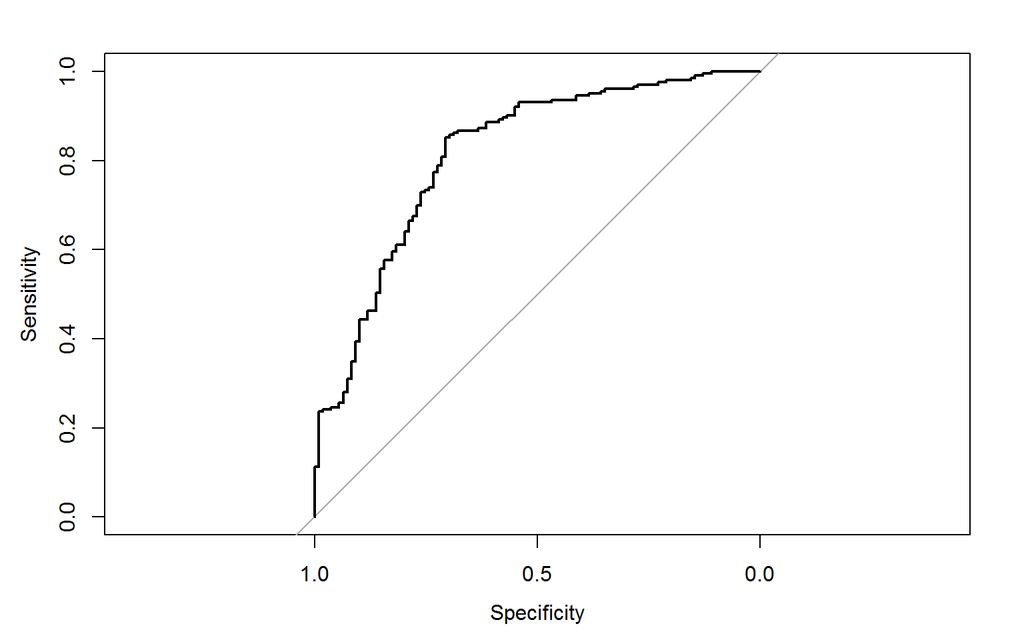

```r
plot(roc_model_ks_glm)
```

```r
roc_model_ks_glm2 <- roc(pbc2$ascities ~ predict(logmodel_ks_glm2, type = "response"), ci = TRUE)
roc_model_ks_glm2
```

```
Call:
roc.formula(formula = pbc2$ascities ~ predict(logmodel_ks_glm2,     type = "response"), ci = TRUE)

Data: predict(logmodel_ks_glm2, type = "response") in 109 controls (pbc2$ascities 0) < 203 cases (pbc2$ascities 1).
Area under the curve: 0.8161
95% CI: 0.7653-0.8669 (DeLong)
```

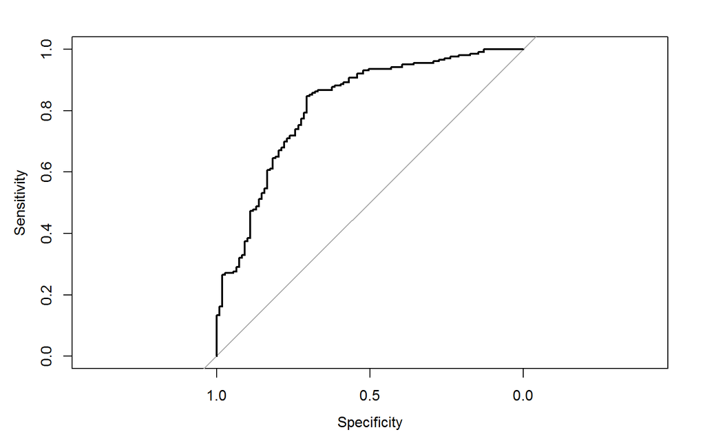

```r
plot(roc_model_ks_glm2)
```

The ROC values are not very different, and model 2 has slightly higher ROC value (0.8161 and 0.8153 for model 2 and model 1 respectively).

### 11.4.4 Calibration

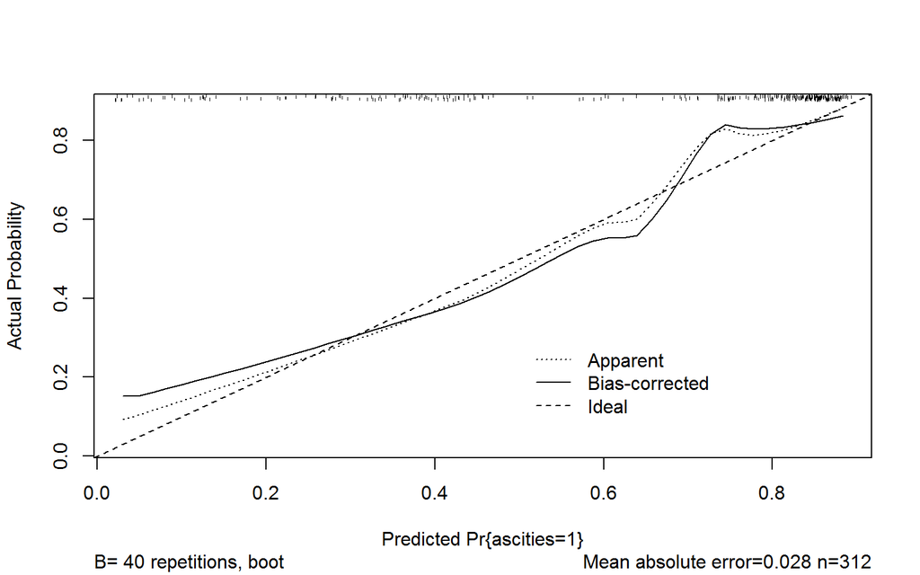

```
n=312   Mean absolute error=0.028   Mean squared error=0.00154
0.9 Quantile of absolute error=0.073
```

```r
plot(calibrate(logmodel_ks_lrm))
```

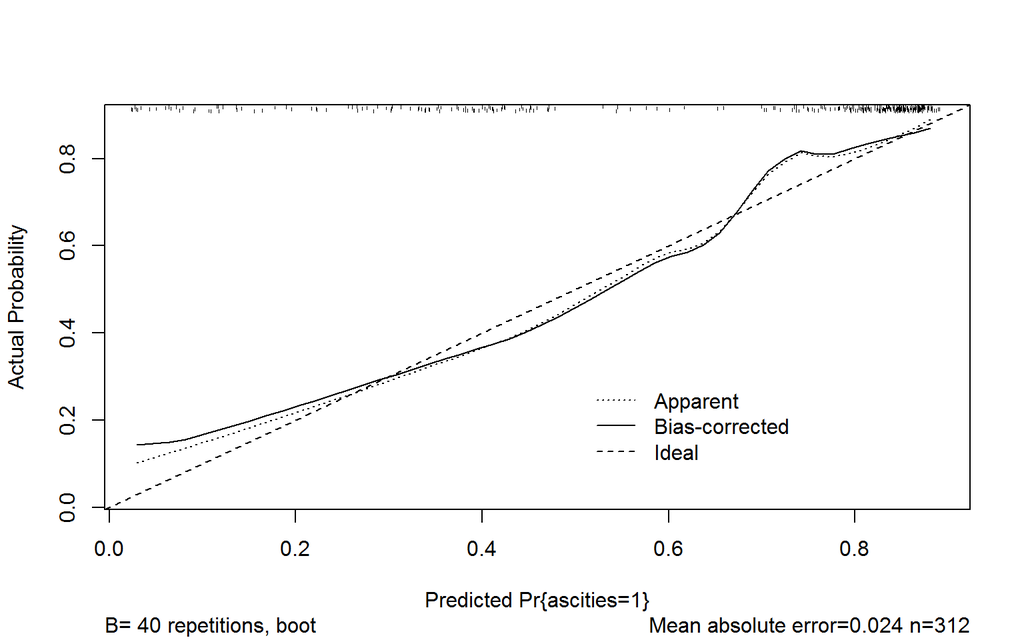

```
n=312   Mean absolute error=0.024   Mean squared error=0.00108
0.9 Quantile of absolute error=0.058
```

```r
plot(calibrate(logmodel_ks_lrm2))
```

The calibration plot for both the models isn’t great.The bias corrected line is both above and below the ideal line, and there are problems in predictions if the predicted values go up. Both the graphs, however, are similar.

### 11.4.5 Validation

```r
validate(logmodel_ks_lrm)
```

```
          index.orig training   test optimism index.corrected  n
Dxy           0.6307   0.6521 0.6215   0.0306          0.6001 40
R2            0.3835   0.4091 0.3714   0.0377          0.3459 40
Intercept     0.0000   0.0000 0.0058  -0.0058          0.0058 40
Slope         1.0000   1.0000 0.9340   0.0660          0.9340 40
Emax          0.0000   0.0000 0.0162   0.0162          0.0162 40
D             0.3231   0.3493 0.3110   0.0382          0.2848 40
U            -0.0064  -0.0064 0.0026  -0.0090          0.0026 40
Q             0.3295   0.3557 0.3085   0.0473          0.2822 40
B             0.1554   0.1485 0.1589  -0.0104          0.1658 40
g             1.4688   1.5637 1.4296   0.1342          1.3346 40
gp            0.2789   0.2865 0.2739   0.0126          0.2663 40
```

```r
validate(logmodel_ks_lrm2)
```

```
          index.orig training   test optimism index.corrected  n
Dxy           0.6322   0.6344 0.6247   0.0097          0.6225 40
R2            0.3826   0.4012 0.3737   0.0275          0.3550 40
Intercept     0.0000   0.0000 0.0406  -0.0406          0.0406 40
Slope         1.0000   1.0000 0.9445   0.0555          0.9445 40
Emax          0.0000   0.0000 0.0196   0.0196          0.0196 40
D             0.3221   0.3417 0.3132   0.0285          0.2936 40
U            -0.0064  -0.0064 0.0006  -0.0070          0.0006 40
Q             0.3285   0.3481 0.3126   0.0355          0.2930 40
B             0.1557   0.1510 0.1582  -0.0073          0.1629 40
g             1.4585   1.5231 1.4274   0.0958          1.3627 40
gp            0.2772   0.2823 0.2733   0.0090          0.2681 40
```

The C-statistic for MOdel 1 is: 0.5 + (0.6307/2) = 0.81535 The C-statistic for model 2 is: 0.5 + (0.6322/2) = 0.8161

Hence, based on all these factors, and the fact that model 2 is easier and spends lesser degrees of freedom, I have decided to go forward with model 2.

## 11.5 Plots

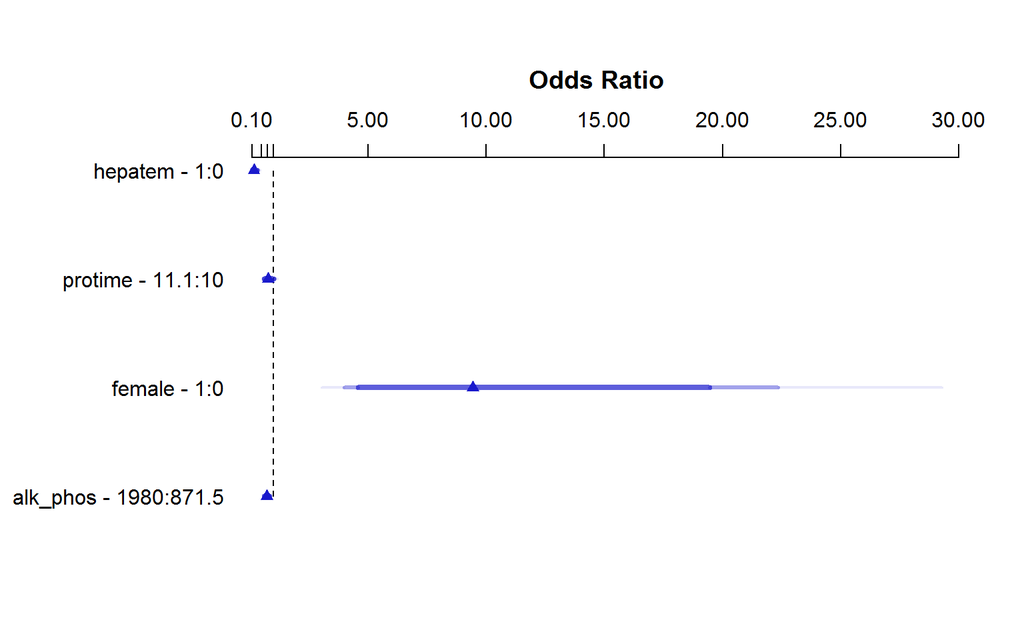

```r
plot(summary(logmodel_ks_lrm2))
```

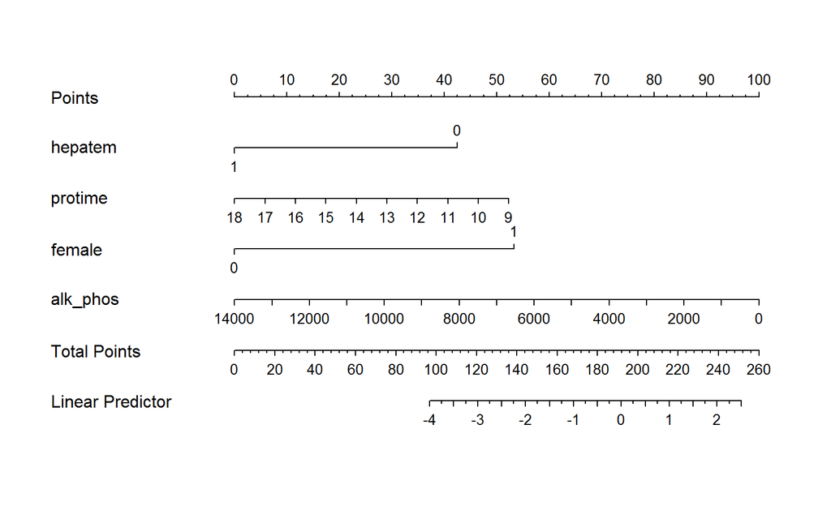

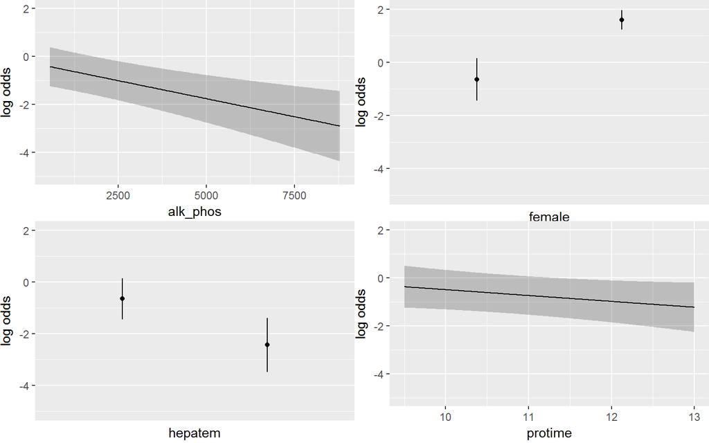

```r
plot(nomogram(logmodel_ks_lrm2))
ggplot(Predict(logmodel_ks_lrm2))
```

Here, we can see that female has a major impact on the odds ratio, and alk_phos is quite the important predictor, as shown by the nomogram, followed by female and protime.

## 11.6 Odds Ratio and Confidence Interval

```r
logmodel_ks_lrm2
```

```
Logistic Regression Model

 lrm(formula = ascities ~ hepatem + protime + female + alk_phos,
     data = pbc2, x = T, y = T)

                       Model Likelihood     Discrimination    Rank Discrim.
                          Ratio Test           Indexes           Indexes
 Obs           312    LR chi2     101.49    R2       0.383    C       0.816
  0            109    d.f.             4    g        1.458    Dxy     0.632
  1            203    Pr(> chi2) <0.0001    gr       4.299    gamma   0.632
 max |deriv| 2e-08                          gp       0.277    tau-a   0.288
                                            Brier    0.156

           Coef    S.E.   Wald Z Pr(>|Z|)
 Intercept  2.3289 1.6167  1.44  0.1497
 hepatem   -1.7884 0.3549 -5.04  <0.0001
 protime   -0.2448 0.1449 -1.69  0.0912
 female     2.2436 0.4404  5.09  <0.0001
 alk_phos  -0.0003 0.0001 -3.52  0.0004
```

```r
summary(logmodel_ks_lrm2)
```

```
             Effects              Response : ascities

 Factor      Low   High   Diff.  Effect   S.E.     Lower 0.95 Upper 0.95
 hepatem       0.0    1.0    1.0 -1.78840 0.354890 -2.484000  -1.092900
  Odds Ratio   0.0    1.0    1.0  0.16722       NA  0.083407   0.335250
 protime      10.0   11.1    1.1 -0.26928 0.159430 -0.581750   0.043191
  Odds Ratio  10.0   11.1    1.1  0.76393       NA  0.558920   1.044100
 female        0.0    1.0    1.0  2.24360 0.440380  1.380400   3.106700
  Odds Ratio   0.0    1.0    1.0  9.42700       NA  3.976700  22.347000
 alk_phos    871.5 1980.0 1108.5 -0.33342 0.094854 -0.519330  -0.147500
  Odds Ratio 871.5 1980.0 1108.5  0.71647       NA  0.594920   0.862860
```

```r
exp(coef(logmodel_ks_glm2))
```

```
(Intercept)     hepatem     protime      female    alk_phos
 10.2662011   0.1672202   0.7828606   9.4269537   0.9996993
```

```r
exp(confint(logmodel_ks_glm2))
```

```
                 2.5 %      97.5 %
(Intercept) 0.40802122 250.6897071
hepatem     0.08206123   0.3316688
protime     0.58701942   1.0449249
female      4.09925808  23.3925816
alk_phos    0.99951465   0.9998535
```

The final equation for the model is: Log odds of Ascities happening = 2.32 - 1.7(hepatem) - 0.24(protime) + 2.24(female) - 0.0003(alk_phos)

The odds ratio indicate that: Females had more odds (9.42 times) of having ascities as compared to males.The 95% CI was (4.099, 23.39) If a person had hepatem (hepatem=1), they had lesser odds of developing ascities (0.16 times). The 95% CI was (0.08, 0.33) If a person’s body took more time for prothrombin formation, they had lesser odds of developing ascities. The 95% CI was (0.58, 1.04) Female, hepatem and alk_phos were all statistically significant in determining whether a person had ascities or not.

# 12 Task 12

For me, the best subsets didn’t work, and my R crashed a couple of times. Thus, I decided to do away with using best subsets, and focussed on stepwise regression. I thought making linear model would be easier, but it was slightly more difficult due to the transformation. I wish I had all the ways of calibration and validation at the back of my head, since I had to look up in the slides every time for this. I also wish I had known how to improve a pre-existing model, since I devoted a lot of time for that. I had to re-read the analysis for models, since I had forgotten how to provide the model summary. Holding onto everything together was really confusing, as I did a lot of analysis, and in-between forgot a lot of stuff which I had planned. Assembling everything together was also confusing. I believe the most useful things I learnt from this project were to calibrate and validate the models and to reduce the number of variables and improve a pre-existing model.

Satyakam Mishra

2018-03-23 12:02:59